# Praca Domowa 3

Ewa Guziewicz

30 października 2018

Poniższy wykres został znaleziony w artykule na stronie ESPN - amerykańskiej całodobowej stacji telewizyjnej poświęconej tematyce sportowej. Artykuł dotyczył przechwyceń biężacych rozgrywkach NFL (National Football League) przez poszczególne drużyny: - CHI: Chicago Bears Team - CIN: Cincinnati Bengals Team - CLE: Cleveland Browns Team - MIA: Miami Dolphins Team - NE: New England Patriots Team - NYJ: New York Jets Team - SEA: Seattle Seahawks Team

## Przed

Wykres prezentował się następująco:

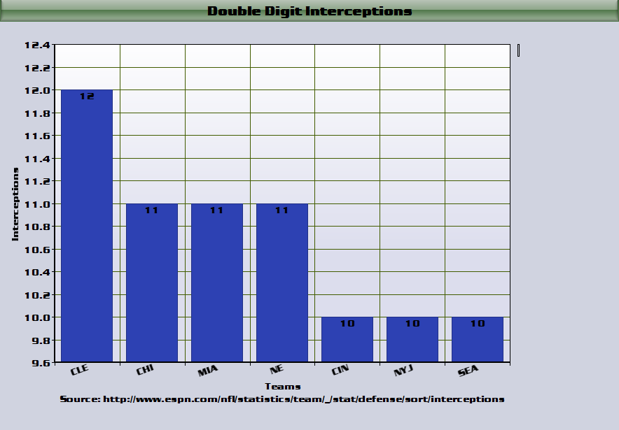

```r
knitr::include_graphics("przed.png")
```

Podstawową wadą wykresu jest umieszczenie części dziesiętnych dla osi Oy, czyli dla liczby przechwyceń. Liczba przechwyceń jest liczbą całkowitą i nie należy zaznaczać na osi wartości, które na pewno nie będą przyjmowane, bo sprawia to wrażenie, jakby wielkości takie mogłyby zostać przyjęte.

## Po

Wykres poprawiony został w następujący sposób:

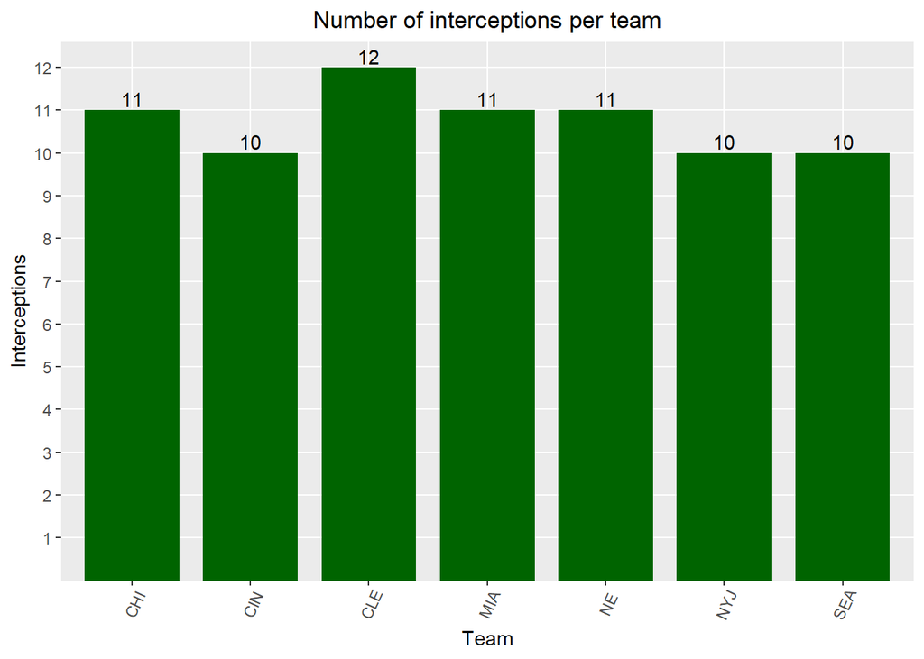

```r
library(ggplot2)
myData <- data.frame(names =  c("CLE", "CHI", "MIA", "NE", "CIN", "NYJ", "SEA"),
                     interceptions = as.factor(c(12, 11, 11, 11, 10, 10, 10)))
cols <- c("10" = "#68229B", "11" = "#9932CC", "12" = "#E066FF")

ggplot(data = myData, aes(x = names, y = interceptions)) +
  scale_y_discrete(limits = c(1:12)) +
  geom_bar(stat="identity", width = 0.8, fill = "darkgreen")  +
  theme(axis.line = element_blank(), plot.title = element_text(hjust=0.5)) +
  labs(title="Number of interceptions per team", x="Team", y = "Interceptions") +
  theme(axis.text.x = element_text(angle=65, vjust=0.6)) +
  geom_text(aes(label=interceptions), position=position_dodge(width=0.9), vjust=-0.25)
```